# Homework 5

Victor Aluko

18 March 2017

## Exercise 1

For this Exercise, I generated the FP-Growth tree as shown below:

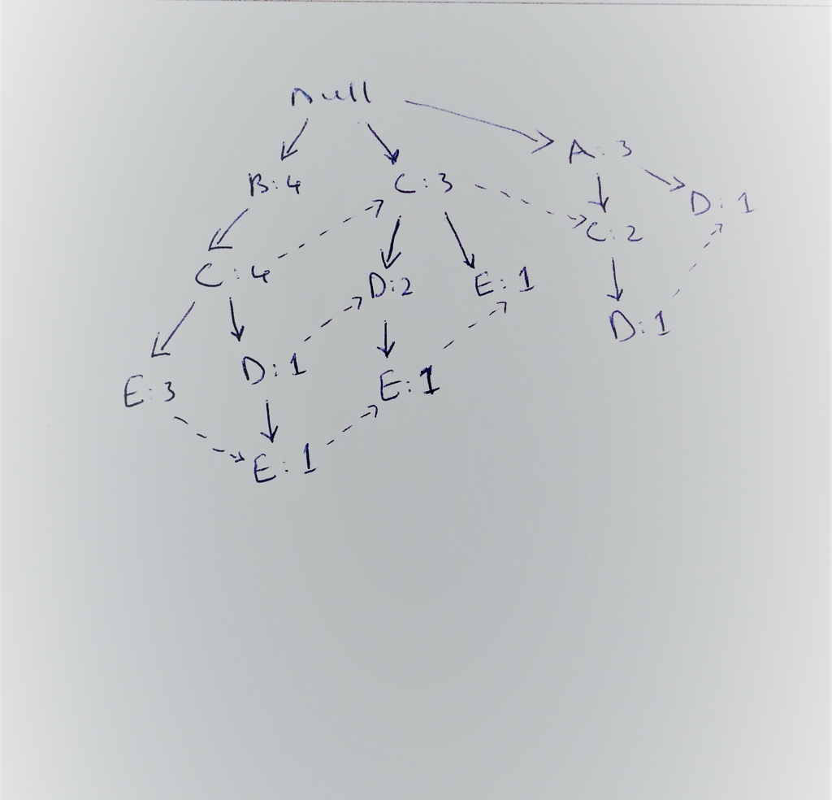

From the FP-Growth tree, the most frequent 3-element itemsets are: B C E, C D E and A C D. One thing that was consistent from the result is that B and C always appeared together in the growth line. From the count of B(4) and C(4), it was consistent that they always followed.

Also there was a bit of consistency between C(4) and E(3)

## Exercise 2

The vertical layout for the elements of the itemset is shown below:

| Itemset | Occurence |
| --- | --- |
| A | 2, 5, 9 |
| B | 3, 4, 8, 10 |
| C | 1, 3, 4, 5, 6, 7, 8, 9, 10 |
| D | 1, 2, 4, 5, 6 |
| E | 1, 3, 4, 7, 8, 10 |

Based on this vertical layout, we can generate a contingency table for BC -> E as shown below:

[output not shown]

I was able to use the vertical layout to determine the availability points to generate the contigency table.

The Odds ratio can be calculated as follows: Odds Ratio = 4 * 6/(2 * 0) = Infinity

## Exercise 3

In order to generate the data, I created 2 random number generators to generate numbers between 50-99 and 1500-3000. The code for the generators are shown below:

```r
big_num_gen <- function() {
  runif(1, 1500, 3000)
}

small_num_gen <- function() {
  runif(1, 50, 99)
}
```

The with these generators, I created 4 functions, to generate with zero, one, two and thress small numbers respectively. In all but the zero small number functions, I used the sample fuinction ro randomize the ordering of the data. Thus, the small number ordering in thesefunctions would be placed at anywhere between the 4 possible slots. I then returned the data as a matrix to generate the contingency table The codes for the functions are below:

```r
no_small <- function() {
  r1 <- big_num_gen()
  r2 <- big_num_gen()
  r3 <- big_num_gen()

  r4 <-  10000 - r1 - r2 - r3

  matrix(c(r1, r2, r3, r4), 2, 2)
}

one_small <- function() {
  r1 <- small_num_gen()
  r2 <- big_num_gen()
  r3 <- big_num_gen()
  r4 <-  10000 - r1 - r2 - r3

  matrix(sample(c(r1, r2, r3, r4)), nrow = 2)
}

two_small <- function() {
  r1 <- small_num_gen()
  r2 <- small_num_gen()
  r3 <- big_num_gen()
  r4 <-  10000 - r1 - r2 - r3

  matrix(sample(c(r1, r2, r3, r4)), nrow = 2)
}

three_small <- function() {
  r1 <- small_num_gen()
  r2 <- small_num_gen()
  r3 <- small_num_gen()
  r4 <-  10000 - r1 - r2 - r3

  matrix(sample(c(r1, r2, r3, r4)), nrow = 2)
}
```

I then used replicate to call each of these functions 2500 times in order to generate a total of 10000 records of contingency tables. The code used for the generation is as follows:

```r
generated_tables = vector(length = 10000)

generated_tables[1:2500] = replicate(2500, no_small(), simplify = FALSE)
generated_tables[2501:5000] = replicate(2500, one_small(), simplify = FALSE)
generated_tables[5001:7500] = replicate(2500, two_small(), simplify = FALSE)
generated_tables[7501:10000] = replicate(2500, three_small(), simplify = FALSE)
```

With these data now generated, I can now go ahead to use the scatterplot package to visualize my data. This can be seen below:

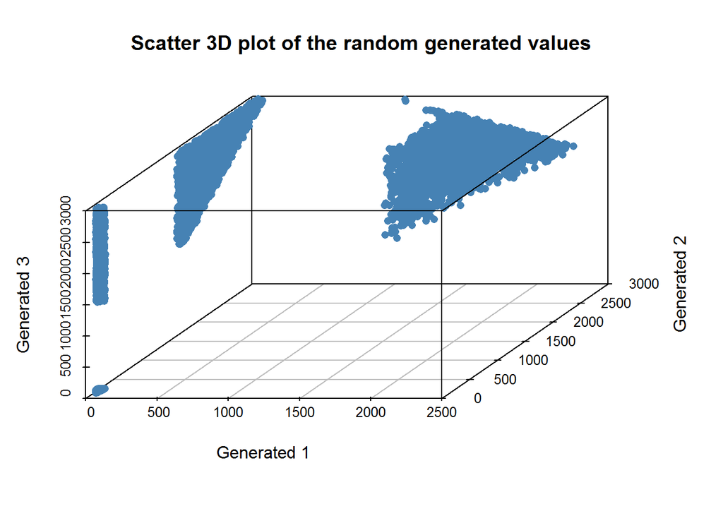

```r
library("scatterplot3d")
GenPlotData <- function(lst) {
  sorted = sort(as.vector(as.matrix(as.data.frame(lst))))
  data.frame(gen1 = sorted[1], gen2 = sorted[2], gen3 = sorted[3])
}

plot_data <- do.call(rbind, lapply(generated_tables, GenPlotData))

scatterplot3d(plot_data, pch = 16, angle = 55, color="steelblue",
              xlab = "Generated 1", ylab = "Generated 2", zlab = "Generated 3",
              grid=TRUE, main = "Scatter 3D plot of the random generated values"
              )
```

## Exercise 4

```
##             lift odds_ratio correlation
## 8385 0.004835600   260.5685  -0.4236323
## 9568 0.004822288   275.5950  -0.4099263
## 8245 0.004635313   191.5954  -0.5188636
## 8043 0.004577699   231.0763  -0.4426762
## 9095 0.004519401   176.5279  -0.4796732
## 9903 0.004517929   257.5916  -0.4159867
```

```
##              lift odds_ratio correlation
## 5340 0.0001362508   6598.525    2.656141
## 6491 0.0001369691   6363.516    2.599838
## 5379 0.0001425479   6228.655    2.259579
## 6191 0.0001321853   6063.406    2.986217
## 7332 0.0001404414   5845.850    2.376245
## 6920 0.0001386009   5815.463    2.486734
```

The contingency tables with the highest Correlation are the contingency tables with 3 small values also. The top correlation values are shown below:

```
##              lift odds_ratio correlation
## 8282 0.0001005077   146.4485    89.92471
## 8363 0.0001005385   169.5733    89.57539
## 9946 0.0001005039   140.7131    89.36243
## 9965 0.0001005122   147.1041    89.29448
## 9343 0.0001005279   154.7477    88.67885
## 9169 0.0001005850   198.8827    87.63730
```

From this data, it shows us that Items with higher price distinction are likely to be found together and bought at the same time, rather than items which are very similar

## Exercise 5